# Machine Learning Model for Human Activity Recognition

### Introduction

Human activity recognition (HAR) research has traditionally focused on discriminating between different activities, i.e. to predict *which* activity was performed at a specific point in time. For the Weight Lifting Dataset we propose to investigate *how well* an activity was performed. This aspect of HAR has potential application in sport training.

The dataset used for this assignement was produced by instructing six participants to perform one set of 10 repetition of the Unilateral Dumbbell Biceps Curl in five different fashions: exactly according to the specification (Class A), throwing the elbows to the front (Class B), lifting the dumbbell only halfway (Class C), lowering the dumbbell only halfway (Class D) and throwing the hips to the front (Class E). Class A corresponds to the specified execution of the exercise, while the other 4 classes correspond to common mistakes.

The original study titled “Qualitative activity recognition of weight lifting exercises”[http://dx.doi.org/10.1145/2459236.2459256] was published in 2013

The goal of the project is to predict **how well** the excercise was performed, i.e. predict the “classe” variable in the dataset.

### Getting and cleaning data

```r
library(caret)
library(corrplot)
library(parallel)
library(doParallel)
```

```r
train_url <-"https://d396qusza40orc.cloudfront.net/predmachlearn/pml-training.csv"
test_url <- "https://d396qusza40orc.cloudfront.net/predmachlearn/pml-testing.csv"
train_file <- "pml-training.csv"
test_file  <- "pml-testing.csv"
if (!file.exists(train_file)) {
  download.file(train_url, destfile=train_file, method = "curl")
}
if (!file.exists(test_file)) {
  download.file(test_url, destfile=test_file, method = "curl")
}

data <- read.csv(train_file, na.strings = c("NA","","#DIV/0!"))
test <- read.csv(test_file, na.strings = c("NA","","#DIV/0!"))
```

### Exploring and cleaning data

The dataset *data* contains 19622 observables and 160 variables.

A summary of data highlight what columns wouldn’t be useful as predictors: - columns that are mostly NA - variables such as column name, user_name, various timestamp (column 1-6) - variable with almost no variability

```r
# Keep columns with less than 30% NA
clean_data <- data[, colSums(is.na(data)) < nrow(data) *0.3]

# Remove near zero variances variables
nzv <- nearZeroVar(clean_data, saveMetrics = T)
clean_data <- clean_data[, !nzv$nzv]

# Remove variable that have no predictive value
clean_data <- clean_data[, -c(1:6)]
```

After cleaning, 53 variables remain. For information, the following figures illustrate the correlation between predictors and the distribution of the “classe” variable.

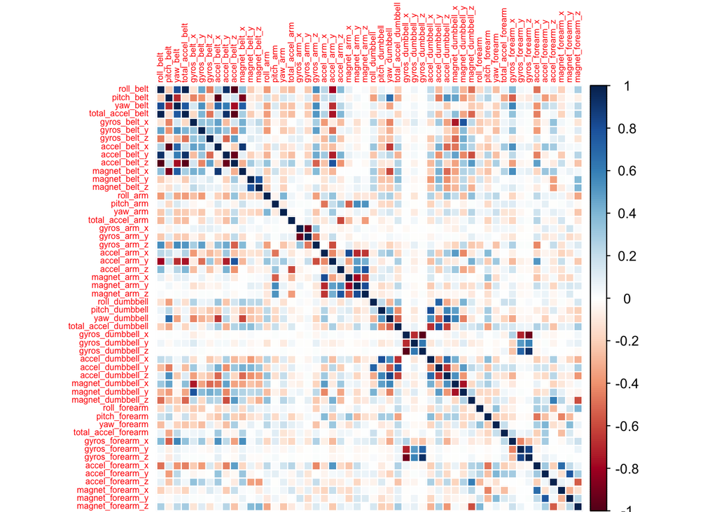

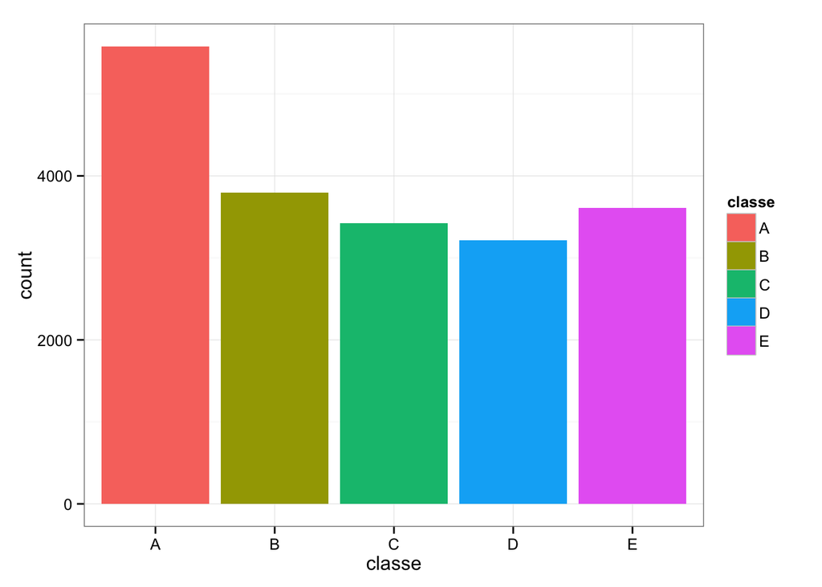

Finaly the cleaned data is partition for model training. A small partition is used to speed up model calculation.

```r
set.seed(9876)
inTrain <- createDataPartition(clean_data$classe, p = 0.3, list = FALSE)
train_data <- clean_data[inTrain,]
valid_data <- clean_data[-inTrain,]
```

### Model generation

Random forest is chosen to model the data. The method is able to handle a large number of features, comprising both unsacled variables and categorical variables. More over random forest is relatively immune to overfitting and is insentitive to feature correlation.

A model is build using Random forest with 5 fold cross validation.

```r
set.seed(1234)
# Parallel execution of code
registerDoParallel(makeCluster(detectCores()))

model_rf<-train(classe~.,data=train_data,method="rf",
                trControl=trainControl(method="cv",number=5),
                prox=TRUE,allowParallel=TRUE)
```

```r
print(model_rf)
```

```
## Random Forest
##
## 5889 samples
##   52 predictor
##    5 classes: 'A', 'B', 'C', 'D', 'E'
##
## No pre-processing
## Resampling: Cross-Validated (5 fold)
## Summary of sample sizes: 4712, 4711, 4710, 4710, 4713
## Resampling results across tuning parameters:
##
##   mtry  Accuracy   Kappa      Accuracy SD  Kappa SD
##    2    0.9762267  0.9699152  0.003935851  0.004980619
##   27    0.9755457  0.9690571  0.005362995  0.006797503
##   52    0.9619632  0.9518699  0.006442329  0.008155843
##
## Accuracy was used to select the optimal model using  the largest value.
## The final value used for the model was mtry = 2.
```

```r
print(model_rf$finalModel)
```

```
##
## Call:
##  randomForest(x = x, y = y, mtry = param$mtry, proximity = TRUE,      allowParallel = TRUE)
##                Type of random forest: classification
##                      Number of trees: 500
## No. of variables tried at each split: 2
##
##         OOB estimate of  error rate: 2.17%
## Confusion matrix:
##      A    B   C   D    E class.error
## A 1666    4   1   2    1 0.004778973
## B   26 1097  15   2    0 0.037719298
## C    1   25 996   5    0 0.030185005
## D    0    0  33 930    2 0.036269430
## E    0    2   3   6 1072 0.010156971
```

### Model evaluation:

The model is used to predict the classe of the validation partition, thus evaluating the out of sample error.

```r
validation_rf <- predict(model_rf, valid_data)
cm <- confusionMatrix(validation_rf, valid_data$classe)
ac <- cm$overall['Accuracy']
print(cm)
```

```
## Confusion Matrix and Statistics
##
##           Reference
## Prediction    A    B    C    D    E
##          A 3888   65    0    0    0
##          B    9 2574   57    0    0
##          C    9   16 2336   85    7
##          D    0    2    2 2162   12
##          E    0    0    0    4 2505
##
## Overall Statistics
##
##                Accuracy : 0.9805
##                  95% CI : (0.978, 0.9827)
##     No Information Rate : 0.2844
##     P-Value [Acc > NIR] : < 2.2e-16
##
##                   Kappa : 0.9753
##  Mcnemar's Test P-Value : NA
##
## Statistics by Class:
##
##                      Class: A Class: B Class: C Class: D Class: E
## Sensitivity            0.9954   0.9688   0.9754   0.9605   0.9925
## Specificity            0.9934   0.9940   0.9897   0.9986   0.9996
## Pos Pred Value         0.9836   0.9750   0.9523   0.9927   0.9984
## Neg Pred Value         0.9982   0.9925   0.9948   0.9923   0.9983
## Prevalence             0.2844   0.1935   0.1744   0.1639   0.1838
## Detection Rate         0.2831   0.1874   0.1701   0.1574   0.1824
## Detection Prevalence   0.2878   0.1922   0.1786   0.1586   0.1827
## Balanced Accuracy      0.9944   0.9814   0.9825   0.9795   0.9961
```

### Test data prediction

Finally, the model is applied to predict the classe of the observations in the test data.

```r
ptest <- predict(model_rf, test)
```

### Coursera submission

Results written in predictions/ directory

```r
answers <- as.vector(ptest)

pml_write_files = function(x){
  path <- "predictions/"
  for(i in 1:length(x)){
    filename = paste0("problem_id_",i,".txt")
    write.table(x[i],file=file.path(path, filename),quote=FALSE,row.names=FALSE,col.names=FALSE)
  }
}
pml_write_files(answers)
```